# Load Test Results

Load test run against http://banff.rstudio.com/content/3. The load test target was **400 total visits** with **400 concurrent users** at a time. Concurrent user sessions were staggered, with a max delay of 20 seconds. Each “user” ran a series of actions against the application as recorded in ./tests/myloadtest.R.

A baseline test was run with **10 total visits** occuring sequentially, one at a time.

## Results

[output not shown]

[output cut: 20 more lines]

[output not shown]

A maximum 343 concurrent connections were achieved, compared to the target of 400.

## Comparison to Baseline

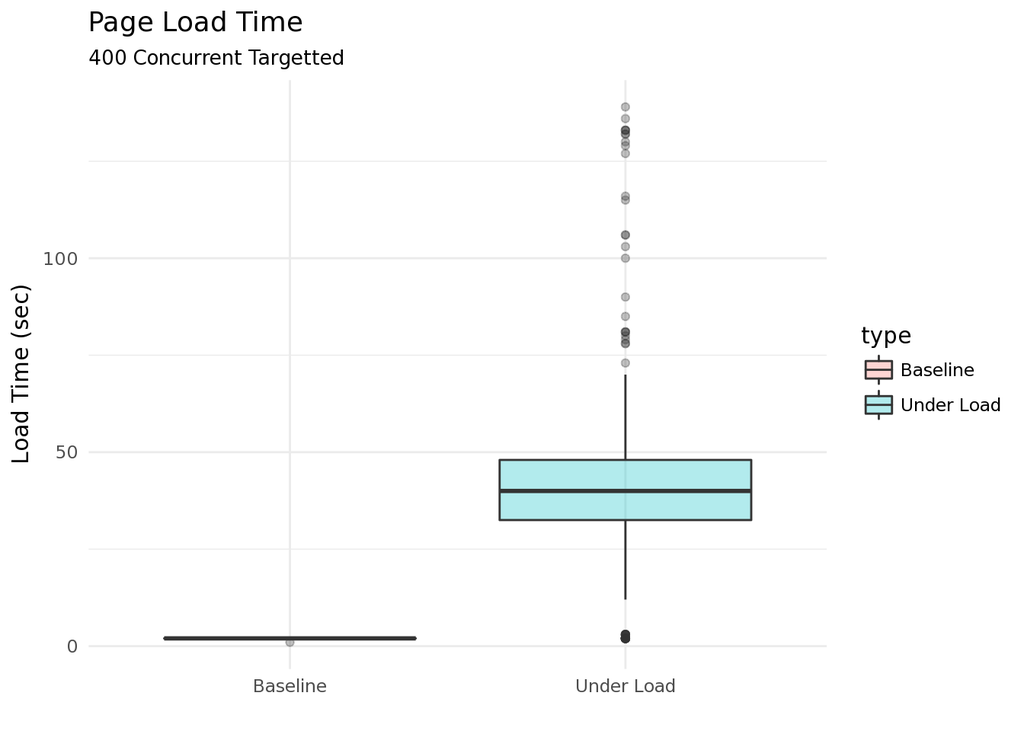

The average page load time under load was 42.5226667 seconds compared to 1.9 seconds with no concurrent load.

The following graph shows the response time for specific events taken after page load. The table lists any events that did not trigger an update pior to the default timeout. For inputs that do not trigger an output (i.e. applications that use action buttons) this is expected behavior.

| Results |
| --- |
| Action 1: beta - 0 of 385 timed out as expected. |
| Action 10: beta - 0 of 385 timed out as expected. |
| Action 11: gamma - 264 of 385 timed out . Warning! Some outputs did not return before the timeout. |
| Action 2: beta - 290 of 385 timed out . Warning! Some outputs did not return before the timeout. |
| Action 3: beta - 255 of 385 timed out . Warning! Some outputs did not return before the timeout. |
| Action 4: beta - 278 of 385 timed out . Warning! Some outputs did not return before the timeout. |
| Action 5: gamma - 267 of 385 timed out . Warning! Some outputs did not return before the timeout. |
| Action 6: gamma - 251 of 385 timed out . Warning! Some outputs did not return before the timeout. |
| Action 7: gamma - 243 of 385 timed out . Warning! Some outputs did not return before the timeout. |
| Action 8: beta - 253 of 385 timed out . Warning! Some outputs did not return before the timeout. |

[output cut: 1 more lines]

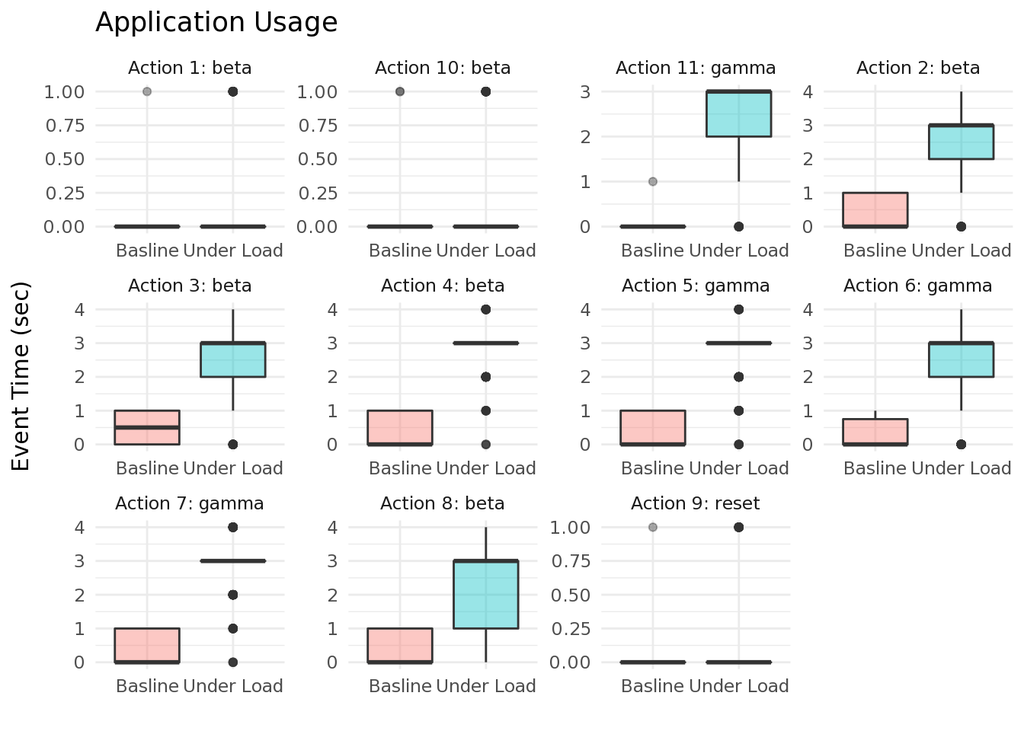

## R Processes

Application latency is often the result of too many users sharing the same R process. RStudio Connect and Shiny Server Pro allow users to be spread across multiple R processes for any application.

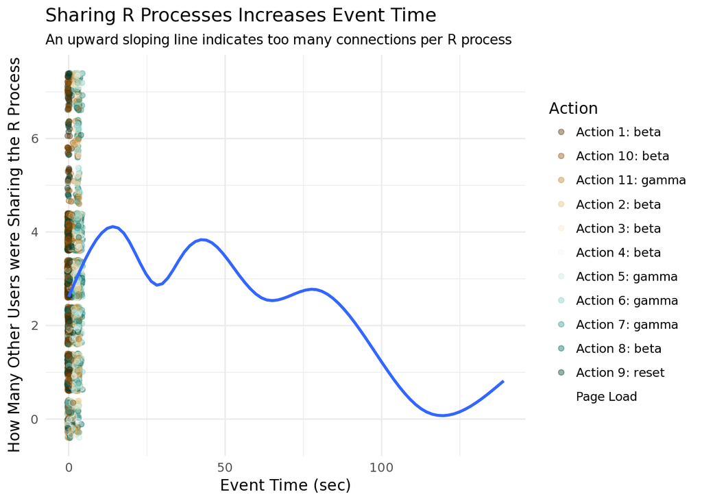